# Coursework Report

*N* removed NAs: 3

*N* removed <18: 20

*N* total clean: 126

| Group | *N* | *M*<sub>age</sub> | *M*<sub>rating</sub> |
| --- | --- | --- | --- |
| Control | 72 | 20.8 | 4.97 |
| Experim | 54 | 20.5 | 5.94 |

**Main analysis results**

*t*(124) = -5.91, *p* < .001

# Coursework Report

Analysing Data, Spring 2020

# Methods

## Participants

| mean | sd | min | max |
| --- | --- | --- | --- |
| NA | 1.55 | 19 | 25 |

[output not shown]

## Design

The study will aim to measure a woman’s perception of a man’s attractiveness in relation to the influence of the colour red and white, a replication of the study by Elliot et al, 2010. Red has been suggested to represent high status and power, thus making a man more attractive to a woman. The study will hypothesise that the picture of the man with a red frame will be rated as more attractive than the picture of the man in a white frame. The red picture frame was the experimental condition and the white frame was the control condition. My study would be a between groups design, as the participants have been allocated to one condition, being the experimental or the control condition. The dependent variable of my study is ‘perceived attractiveness’ which is a rating that the women carried out when answering the three questions in the experiment about the man in the picture. Perceived attractiveness is a rating that was created by adding up the answers of the 3 questions and then dividing that total by 3. The 3 questions that the participants had to answer were “How attractive do you think this person is?”, “How pleasant is this person to look at?” and “If I were to meet this person face to face, I would think he is attractive.”. The participants answered on a 9 point scale, 9 being “extremely attractive”. The higher the perceived attractiveness is, the more attractive the women found the man.The ‘control’ group was the picture of the man in a white frame whilst the ‘experimental’ group was the picture of the man in a red frame. The picture was placed in a page that was 8.5 inches by 11.5 inches. The operational hypothesis is that the women in the ‘experimental’ group will find the man more attractive than the women in the ‘control’ group and will rate the three questions higher than the ‘control’ group. I will test this hypothesis by using a t-test.

# Results

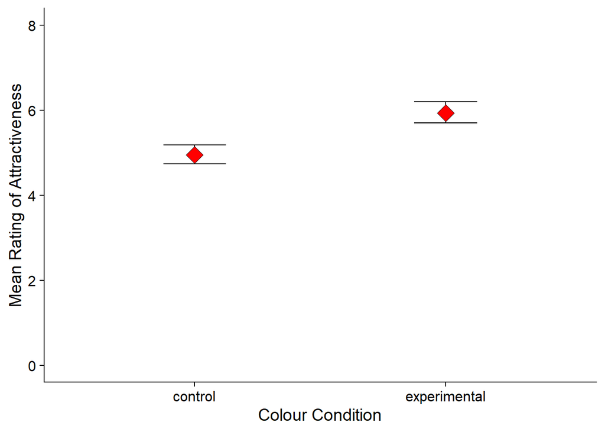

# Discussion

My results showed that the ‘experimental’ group, being the women who looked at the man in the red picture frame, rated the man as more attractive than the women in the ‘control’ group with the white picture frame. There was not a huge difference but it was clear that the women found the man with the red frame more attractive than the man in the white frame, despite it being the same Caucasian man in both picture frames. In relation to the original study by Elliot et al, my results support the findings form this study as Elliot et al. also found that women rated the man more attractive in the ‘experimental’ condition compared to the ‘control’ condition. In Elliot et al.’s study, the mean perceived attractiveness in the red condition was 6.79 whilst the white condition was 5.67, suggesting that the women found the man with the red frame more attractive than the white frame. I think this proves the notion that the colour red on men is attractive to women as it displays a sense of power, strength and masculinity, which most women find important in a mating partner. A replication of Elliot’s study, by Hesslinger et al., 2015, furthermore found similar findings to Elliot et al’s study. Hesslinger conducted the study in Germany and used the same Caucasian man that was used in Elliot’s study and placed the picture of the man on paper with a red or white background, instead of a picture frame. The participants were split into a red or white group and looked at one photo for 5 seconds and rated the man’s attractiveness based on the three questions they were asked. The questions were the same ones used in Elliot’s study. Generally, Elliot and Hesslinger et al found similar results, with the red condition being rated as more attractive than the white condition, but only slightly. In the red condition of Hesslinger, the mean overall perceived attractiveness was 5.71, whilst the white condition was 5.39. A strength of my study is that the participants were university students, which included international students and therefore creates high population validity, generalising the results to females aged 19-25 around the world. However a weakness of my study is that the oldest woman was 25 years old, thus proving that the results are not generalisable to women over the age of 25, suggesting the results do also lack population validity. Despite this, my results are generally very similar to Elliot et al’s. and Hesslinger et al’s, proving that the pattern of attractiveness was supported in all three studies, suggesting that women do ultimately find men more attractive in red compared to white. Additionally, Hesslinger’s study had ages ranging from 18 to 51 years old, thus including older women and gaining the same effect as my study and Elliot et al.’s study. In a future study, I think it would be interesting to use other block colours, to compare with red, such as blue, green and yellow. This is because the previous studies have solely focussed on red and white, rather than other colours that may also enhance a man’s attractiveness. To conclude, my experiment does support the hypothesis that the picture of the man in the red frame will be rated as more attractive than the man in the white frame, suggesting that women do find men more attractive in red than white.

# References

Red, Rank and romance in women viewing men (Elliot el at., 2010)

Men in red: A reexamination of the red- attractiveness effect (Hesslinger, Goldbach, & Carbon, 2015)